```python
import numpy as np
import pylab as pl
import scipy as sp
import matplotlib.pyplot as plt
import pandas as pd
pd.set_option('display.precision', 2)
```

```python
from sklearn.model_selection import GridSearchCV
from sklearn.model_selection import TimeSeriesSplit, PredefinedSplit
```

# 1 - Constants

```python
fig_size = (25,8)
```

```python
## Define number of signals to display
Nb_signals = 2
```

```python
## Define training set size
training_size = 1500
val_size = 1000
```

# 2 - Data Visualisation and pre-processing

```python
data_ecog = np.load("ECoG.npz")
```

```python
fq = data_ecog["Fe"][0][0].item()
fq
```

```
50
```

```python
X = data_ecog["Xall"]
Nb_features = len(X[0])
data_size = len(X)
data_size, Nb_features
test_size = data_size - training_size - val_size
```

```python
Y = data_ecog["Yall"]
len(Y), len(Y[0])
```

```
(3327, 1)
```

Let's check that the features all have the same scaling

```python
len(X)
```

```
3327
```

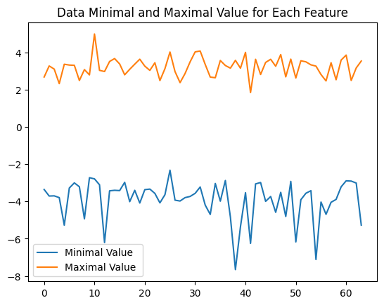

```python
mins, maxs = [], []
for i in range(64) :
    mins.append(np.min(X[:,i]))
    maxs.append(np.max(X[:,i]))

plt.figure()
plt.plot(mins, label = "Minimal Value")
plt.plot(maxs, label = "Maximal Value ")
plt.legend()
plt.title("Data Minimal and Maximal Value for Each Feature")
plt.show()
```

We can deduce that the scaling is approximatively the same and that no scaler is needed for this data

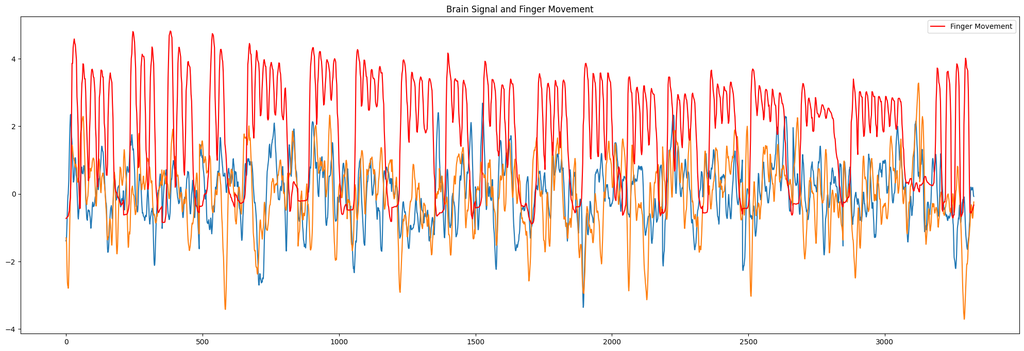

```python
plt.figure(figsize = (25,8))
X_transpose = X.T
# Adapter affichage des labels en fonction du nombre de signaux affichés
for x in X_transpose[:Nb_signals] :
    plt.plot(x)
plt.plot(Y, c = 'red', label = 'Finger Movement')
plt.legend()
plt.title("Brain Signal and Finger Movement")
plt.show()
```

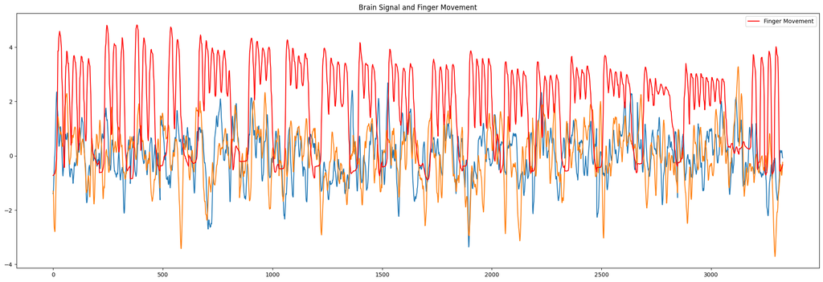

```python
plt.figure(figsize = (25,8))
X_transpose = X.T
for x in X_transpose[:Nb_signals] :
    plt.plot(x)
plt.plot(Y, c = 'red', label = 'Finger Movement')
plt.legend()
plt.title("Brain Signal and Finger Movement")
plt.show()
```

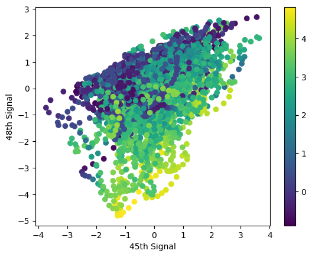

```python
plt.figure()
plt.scatter(X_transpose[45], X_transpose[48], c = Y, cmap = 'viridis')
plt.xlabel("45th Signal")
plt.colorbar()
plt.ylabel("48th Signal")
plt.show()
```

Features 45 and 48 seems to be highly responsible of the value of the finger flexion, maybe the 48th signal has agreater influence on the result as the value of the finger flexion seems to increase as this signal value's diminishes. Also the 45th signal value seems to have a slight positive influence on the finger flexion signal. We'll check if these features are used in our models.

Let's display their signal and the finger flexion to see if we see some correspondance between them

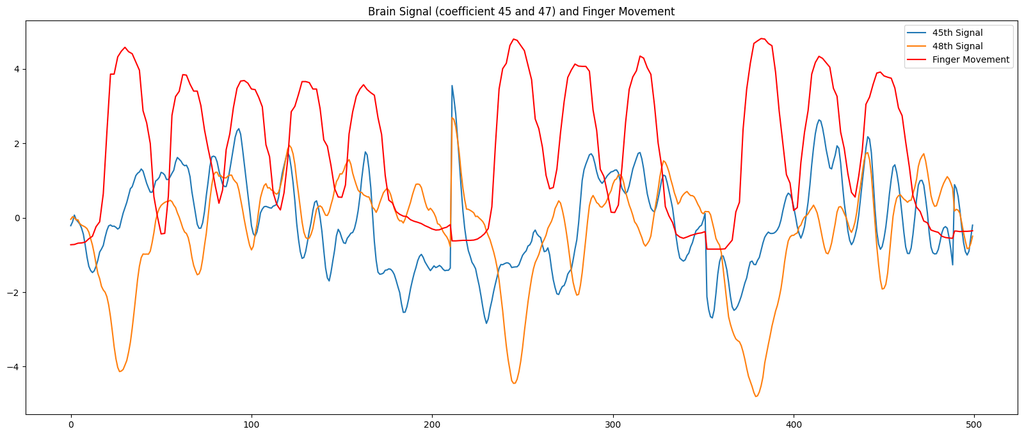

```python
plt.figure(figsize = (20,8))
X_transpose = X.T
plt.plot(X_transpose[45][:500], label = '45th Signal')
plt.plot(X_transpose[48][:500], label = '48th Signal')

plt.plot(Y[:500], c = 'red', label = 'Finger Movement')
plt.legend()
plt.title("Brain Signal (coefficient 45 and 47) and Finger Movement")
plt.show()
```

```python
training_size, val_size
```

```
(1500, 1000)
```

```python
X_train = X[:training_size]
X_val = X[training_size:training_size+val_size]
X_test = X[training_size+val_size : ]
```

```python
Y_train = Y[:training_size]
Y_val = Y[training_size:training_size+val_size]
Y_test = Y[training_size+val_size : ]
```

# 3 - Least Square Regression

```python
X_train_reg = np.concatenate((X_train, np.ones((training_size, 1))), axis = 1)
len(X_train_reg), len(X_train_reg[0])
```

```
(1500, 65)
```

```python
theta = np.linalg.solve(np.dot(X_train_reg.T, X_train_reg), np.dot(X_train_reg.T, Y_train))
```

```python
weights = theta.T[0][:Nb_features]
bias = theta.T[0][-1].item()
bias
```

```
1.8640869847013914
```

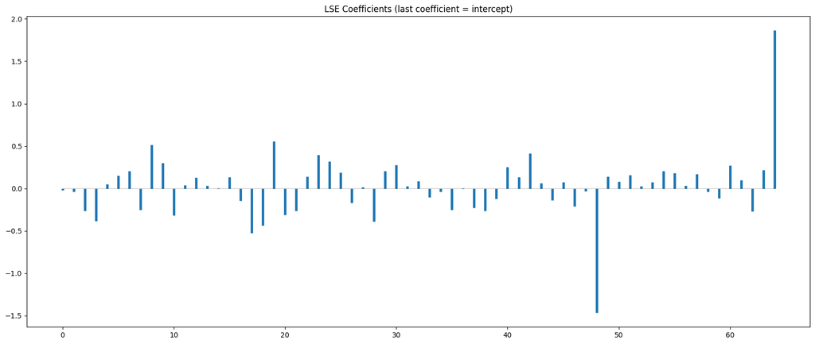

```python
plt.figure(figsize = (20,8))
markerline1, stemlines1, baseline1 = plt.stem(np.arange(Nb_features+1),theta.T[0] , linefmt='C0-', markerfmt=' ', basefmt='k-', label = "Features Weights")
plt.setp(stemlines1, color ='tab:blue', linewidth=3.5)
plt.setp(markerline1, 'color', 'tab:blue')
plt.setp(baseline1, color='black', linewidth=0.2)
plt.title("LSE Coefficients (last coefficient = intercept)")
plt.show()
```

```python
m = np.max(np.abs(weights))
amabs = np.argmax(np.abs(weights))
print("The Strongest Coefficient in Absolute Value is " , amabs , " : ",m)
print("----------------------------------------")
print("45th coefficient value :  " , weights[45])
print("48th coefficient value :  " , weights[48])
```

```
The Strongest Coefficient in Absolute Value is  48  :  1.4678967031418888
----------------------------------------
45th coefficient value :   0.07297410774807267
48th coefficient value :   -1.4678967031418888
```

We can observe that the trained model contains a non negligible intercept and that the most important coefficient in absolute value is the 48th, a result which is coherent with what we observed on the scatterplot. Concerning the 45th coefficient, its value is almost negligible.

```python
am = np.argmin(weights)
aM = np.argmax(weights)
am, aM
```

```
(np.int64(48), np.int64(19))
```

Let's display the scatterplot between the 48th signal and the signal corresponding to the second highest absolute coefficient : the 19th. So we'll see if the low absolute value of the 45th coefficient is coherent.

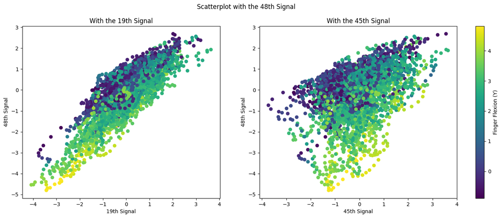

```python
fig, axs = plt.subplots(1,2, figsize = (16,6))

sc1 = axs[0].scatter(X_transpose[19], X_transpose[48], c = Y, cmap = 'viridis')
axs[0].set_xlabel("19th Signal")
axs[0].set_ylabel("48th Signal")
axs[0].set_title("With the 19th Signal")

axs[1].scatter(X_transpose[45], X_transpose[48], c = Y, cmap = 'viridis')
axs[1].set_xlabel("45th Signal")
axs[1].set_ylabel("48th Signal")
axs[1].set_title("With the 45th Signal")

cbar = fig.colorbar(sc1, ax=axs, orientation='vertical', fraction=0.02, pad=0.04)
cbar.set_label("Finger Flexion (Y)")
plt.suptitle("Scatterplot with the 48th Signal")
plt.show()
```

Indeed the 19th signal seems to have a greater (positive) influence on finger flexion than the 45th. We can also observe that the 19th signal is more correlated to the 48th signal than the 45th.

Regarding linear regression, multicolinearity can have disadvantagous side effects as instable coeffficients, bad generalization and also a loss of interpretability (as high coefficients on correlated features is sometimes just a side effect of their correlation with the other and not reflect their true importance).

Let's select the 15 "most important" features according to their absolute coefficient and display their correlation

```python
n = 15

abs_weights = np.abs(weights)

indices_top = np.argpartition(abs_weights, -n)[-n:]
indices_top_sorted = indices_top[np.argsort(abs_weights[indices_top])[::-1]]
```

```python
indices_top_sorted
```

```
array([48, 19, 17,  8, 18, 42, 23, 28,  3, 10, 24, 20,  9, 30, 60])
```

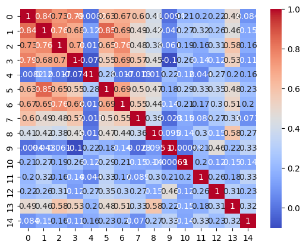

```python
import seaborn as sns

sns.heatmap(pd.DataFrame(X[:, indices_top_sorted]).corr(), cmap='coolwarm', annot=True)
```

We indeed can observe that the 7 most important features (except the 18th signal) are highly correlated, while other features of the top 15 are also correlated to top features, especially to the 48th signal. We'll see if regularization adesses this issue.

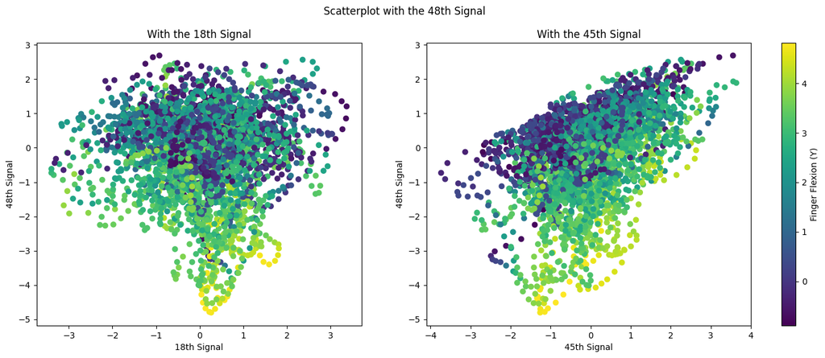

```python
fig, axs = plt.subplots(1,2, figsize = (16,6))

sc1 = axs[0].scatter(X_transpose[18], X_transpose[48], c = Y, cmap = 'viridis')
axs[0].set_xlabel("18th Signal")
axs[0].set_ylabel("48th Signal")
axs[0].set_title("With the 18th Signal")

axs[1].scatter(X_transpose[45], X_transpose[48], c = Y, cmap = 'viridis')
axs[1].set_xlabel("45th Signal")
axs[1].set_ylabel("48th Signal")
axs[1].set_title("With the 45th Signal")

cbar = fig.colorbar(sc1, ax=axs, orientation='vertical', fraction=0.02, pad=0.04)
cbar.set_label("Finger Flexion (Y)")
plt.suptitle("Scatterplot with the 48th Signal")
plt.show()
```

Indeed the scatterplot of 18th and 48th signal don't seem to contains correlation of some sort.

Now let's observe the quality of the prediction made by the model.

```python
## Compute linear regression output for train and test data

# Train data
Y_train_pred = np.dot(X_train_reg, theta)

# Test data
X_test_reg = np.concatenate((X_test, np.ones((test_size, 1))), axis = 1)
Y_test_pred = np.dot(X_test_reg, theta)

len(Y_train_pred), len(Y_test_pred)
```

```
(1500, 827)
```

```python
## Display Prediction Results

def display_results(Y_pred, Y) :
    plt.figure(figsize= fig_size)
    plt.plot(Y, label = 'Finger Flexion (Ground Truth)')
    plt.plot(Y_pred, label = 'Flexion Predicted by LSE')
    plt.legend()
```

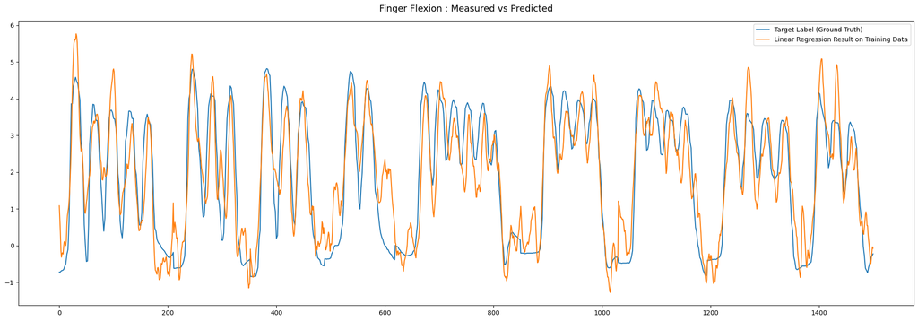

```python
plt.figure(figsize= (16,6))
display_results(Y_train_pred, Y_train)
plt.title("Finger Flexion : Measured vs Predicted", fontsize = 14, y = 1.02)
plt.show()
```

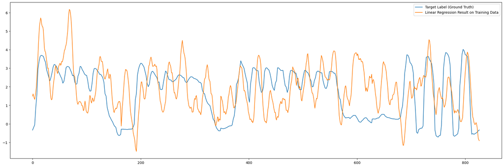

```python
plt.figure(figsize= fig_size)
display_results(Y_test_pred, Y_test)
plt.show()
```

The prediction seems very good on the training data but not so good on test data. We can conclude that this LSE model overfits training data.

```python
from sklearn.metrics import mean_squared_error
from sklearn.metrics import r2_score
```

```python
## Compute MSE
MSE_train = mean_squared_error(Y_train, Y_train_pred)
MSE_test = mean_squared_error(Y_test, Y_test_pred)
print("MSE train : ", MSE_train)
print("MSE test : ", MSE_test)
print("-------------------------")

## Compute R2
R2_train = r2_score(Y_train, Y_train_pred)
R2_test = r2_score(Y_test, Y_test_pred)
print("R2 train : ", R2_train)
print("R2 test : ", R2_test)
```

```
MSE train :  0.632223804273292
MSE test :  2.2721952185215444
-------------------------
R2 train :  0.792845183598481
R2 test :  -0.3168289001268394
```

```python
# Save the results for further comparison

perfs = pd.DataFrame(
    {"MSE Train" : MSE_train, "MSE Test" : MSE_test, "R2 Train" : R2_train, "R2 Test" : R2_test},
    index = ["LSE"]
    )
perfs
```

|  | MSE Train | MSE Test | R2 Train | R2 Test |
| --- | --- | --- | --- | --- |
| LSE | 0.63 | 2.27 | 0.79 | -0.32 |

We observe numerically the overfitting observed on predicted signal. R2 is negative, meaning that the prediction on the test data is less efficient than the mean of the training labels

```python
mean_train = np.mean(Y_train)
pred_mean = [mean_train for i in range(len(X_test))]

## Compute MSE
MSE_mean = mean_squared_error(Y_test, pred_mean)
print("MSE test LSE : ", MSE_test)
print("MSE test mean : ", MSE_mean)
print("-------------------------")

## Compute R2
R2_mean = r2_score(Y_test, pred_mean)
print("R2 test LSE: ", R2_test)
print("R2 test mean : ", R2_mean)
```

```
MSE test LSE :  2.2721952185215444
MSE test mean :  1.758938674690965
-------------------------
R2 test LSE:  -0.3168289001268394
R2 test mean :  -0.01937600321638122
```

The LSE prediction is even wose than the simple model drawing an horizontal line at the mean of Y_train.

Let's check that sklearn LSE gives the result we obtained by computing the coefficients manually :

```python
from sklearn import linear_model
```

```python
lin_reg = linear_model.LinearRegression()
lin_reg.fit(X_train, Y_train)
```

```
LinearRegression()
```

```python
lin_reg.intercept_
```

```
array([1.86408698])
```

```python
## Detecting coefficients significatively different

diff_coefs_ids = []
coefs = lin_reg.coef_[0]
for i in range(len(theta)-1) :
    if abs(coefs[i] - theta[i])>10e-8 :
        print(coefs[i], theta[i])
        diff_coefs_ids.append(i)
if abs(lin_reg.intercept_[0] - theta[-1])>10e-8 :
    print(lin_reg.intercept_[0] -theta[-1])
    diff_coefs_ids.append(len(theta))

diff_coefs_ids
```

```
[]
```

All the coeffifients of the resulting Linear Regression corresponds to the ones computed.

# 4 - Ridge Regression

```python
from sklearn.linear_model import Ridge
```

```python
reg_ridge = Ridge(alpha = 1)
reg_ridge.fit(X_train, Y_train)
y_pred_train_ridge, y_pred_test_ridge = reg_ridge.predict(X_train), reg_ridge.predict(X_test)
```

```python
## Compute MSE
MSE_train_ridge = mean_squared_error(Y_train, y_pred_train_ridge)
MSE_test_ridge = mean_squared_error(Y_test, y_pred_test_ridge)
print("MSE train : ", MSE_train_ridge)
print("MSE test : ", MSE_test_ridge)

print("-------------------------")

## Compute R2
R2_train_ridge = r2_score(Y_train, y_pred_train_ridge)
R2_test_ridge = r2_score(Y_test, y_pred_test_ridge)
print("R2 train : ", R2_train_ridge)
print("R2 test : ", R2_test_ridge)
```

```
MSE train :  0.6322558369898872
MSE test :  2.258004027921842
-------------------------
R2 train :  0.7928346877400836
R2 test :  -0.3086045320106807
```

The results are exactly the same than the linear regression without regularization

```python
alphas = [10 **k for k in range(-3, 6)]
alphas
```

```
[0.001, 0.01, 0.1, 1, 10, 100, 1000, 10000, 100000]
```

```python
def search_alpha(typ : str, alphas,  X_train = X_train, X_test = X_test, Y_train = Y_train, Y_test = Y_test, X_val = X_val, Y_val = Y_val) :

    ridges = []

    ridge_MSEs_train = []
    ridge_MSEs_test = []
    ridge_MSEs_val = []

    ridge_R2s_train = []
    ridge_R2s_test = []
    ridge_R2s_val = []

    ridge_coefs = []
    ridge_bias = []

    for a in alphas :
        if typ == 'ridge' :
            reg_ridge = Ridge(alpha = a)
        elif typ == 'lasso' :
            reg_ridge = Lasso(alpha = a)

        reg_ridge.fit(X_train, Y_train)
        y_tr_temp = reg_ridge.predict(X_train)
        y_va_temp = reg_ridge.predict(X_val)
        y_te_temp = reg_ridge.predict(X_test)

        ridge_coefs.append(reg_ridge.coef_)
        ridge_bias.append(reg_ridge.intercept_)

        MSE_tr_temp = mean_squared_error(Y_train, y_tr_temp)
        MSE_va_temp = mean_squared_error(Y_val, y_va_temp)
        MSE_te_temp = mean_squared_error(Y_test, y_te_temp)

        ridge_MSEs_train.append(MSE_tr_temp)
        ridge_MSEs_val.append(MSE_va_temp)
        ridge_MSEs_test.append(MSE_te_temp)


        R2_tr_temp = r2_score(Y_train, y_tr_temp)
        R2_va_temp = r2_score(Y_val, y_va_temp)
        R2_te_temp = r2_score(Y_test, y_te_temp)
        ridge_R2s_train.append(R2_tr_temp)
        ridge_R2s_val.append(R2_va_temp)
        ridge_R2s_test.append(R2_te_temp)

        ridges.append(reg_ridge)

    return ridges, ridge_MSEs_train, ridge_MSEs_val, ridge_MSEs_test, ridge_R2s_train, ridge_R2s_val, ridge_R2s_test, ridge_coefs, ridge_bias
```

```python
ridges, ridge_MSEs_train, ridge_MSEs_val, ridge_MSEs_test, ridge_R2s_train, ridge_R2s_val, ridge_R2s_test, ridge_coefs, ridge_bias = search_alpha('ridge', alphas)
```

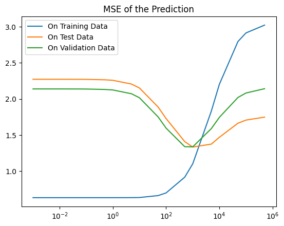

```python
plt.figure()
plt.plot(alphas, ridge_MSEs_train, label = 'On Training Data')
plt.plot(alphas, ridge_MSEs_test, label = 'On Test Data')
plt.plot(alphas, ridge_MSEs_val, label = 'On Validation Data')

plt.xscale('log')
plt.title("MSE of the Prediction")
plt.legend()
plt.show()
```

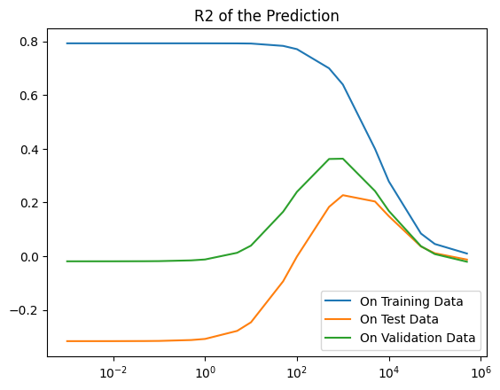

```python
plt.figure()
plt.plot(alphas, ridge_R2s_train, label = 'On Training Data')
plt.plot(alphas, ridge_R2s_test, label = 'On Test Data')
plt.plot(alphas, ridge_R2s_val, label = 'On Validation Data')

plt.xscale('log')
plt.legend()
plt.title("R2 of the Prediction")
plt.show()
```

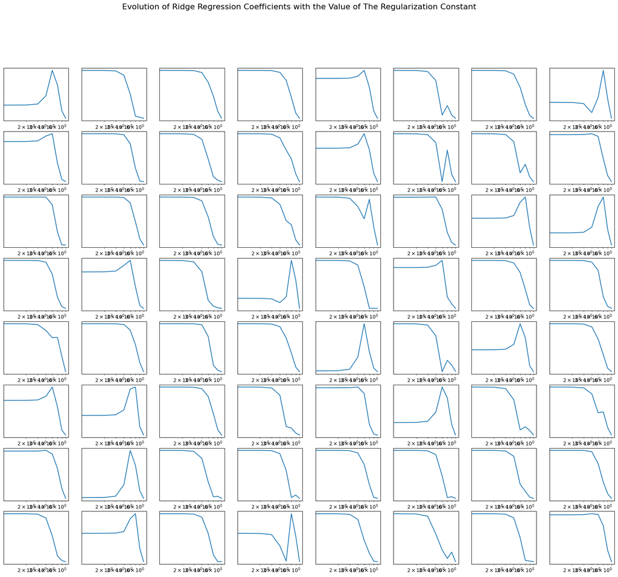

```python
def display_coefs_evol(coefs) :
    nb_coefs = len(coefs[0])
    coefs = np.array(coefs)
    fig, axs = plt.subplots(nb_coefs//8, 8, figsize = (22, 18))
    for i in range(nb_coefs) :
        axs[i%8, i//8].plot(np.abs(coefs[:, i]))
        axs[i%8, i//8].set_xscale('log')
        axs[i%8, i//8].set_xticks([])
        axs[i%8, i//8].set_yticks([])
    plt.suptitle("Evolution of Ridge Regression Coefficients with the Value of The Regularization Constant", fontsize = 16)

display_coefs_evol(ridge_coefs)
plt.show()
```

Given the multiplicity of scales on each coefficient's evolution (some are positive, other negatives), we display their absolute value, so we can observe if they converge to 0 with alpha increasing. And indeed that's the case.

Let's display the 48th, 45th and 19th coefficients :

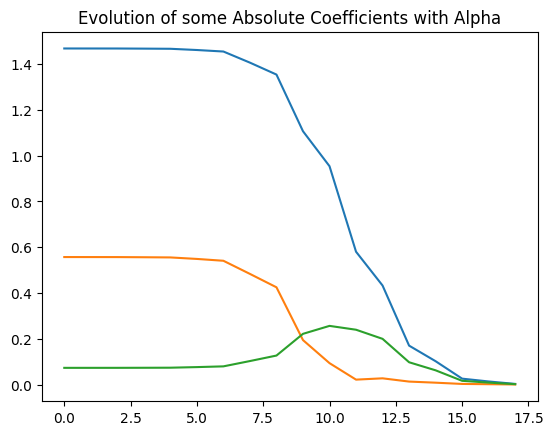

```python
plt.figure()

plt.plot(np.abs(np.array(ridge_coefs))[:,48], label = '48th Coefficient')
plt.plot(np.abs(np.array(ridge_coefs))[:,19], label = '19th Coefficient')
plt.plot(np.abs(np.array(ridge_coefs))[:,45], label = '45th Coefficient')

plt.title("Evolution of some Absolute Coefficients with Alpha")
plt.show()
```

The value of alpha providing the best MSE and R2 seems to be 10^3, on test and validation data.

```python
idx_ridge = np.argmin(ridge_MSEs_test)
ridge = ridges[idx_ridge]
ridge
```

```
Ridge(alpha=1000)
```

```python
Y_train_pred_ridge = ridge.predict(X_train)
Y_test_pred_ridge = ridge.predict(X_test)
```

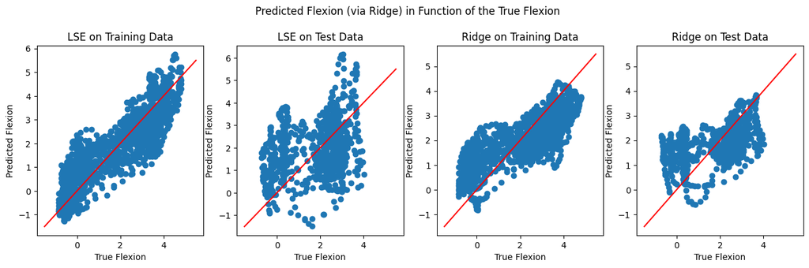

```python
fig, axs = plt.subplots(1,4, figsize = (16,4))

axs[0].scatter(Y_train, Y_train_pred)
line = np.linspace(-1.5,5.5, 100)
axs[0].plot(line, line, color = 'red')
axs[0].set_title("LSE on Training Data")
axs[0].set_ylabel("Predicted Flexion")
axs[0].set_xlabel("True Flexion")

axs[1].scatter(Y_test, Y_test_pred)
line = np.linspace(-1.5,5.5, 100)
axs[1].plot(line, line, color = 'red')
axs[1].set_title("LSE on Test Data")
axs[1].set_ylabel("Predicted Flexion")
axs[1].set_xlabel("True Flexion")

axs[2].scatter(Y_train, Y_train_pred_ridge)
line = np.linspace(-1.5,5.5, 100)
axs[2].plot(line, line, color = 'red')
axs[2].set_title("Ridge on Training Data")
axs[2].set_ylabel("Predicted Flexion")
axs[2].set_xlabel("True Flexion")

axs[3].scatter(Y_test, Y_test_pred_ridge)
line = np.linspace(-1.5,5.5, 100)
axs[3].plot(line, line, color = 'red')
axs[3].set_title("Ridge on Test Data")
axs[3].set_ylabel("Predicted Flexion")
axs[3].set_xlabel("True Flexion")

plt.suptitle("Predicted Flexion (via Ridge) in Function of the True Flexion", y = 1.04)

plt.show()
```

- For the LSE : We can observe that for the training data the scatter between predicted flexion and true flexion is looking like the identity (the ridge performs well on training data) but that is not really the case for the test data.
- For the Ridge : The prediction fits less the identity for the training predictions but the predictions on the test data are closer to this diagonal. This is due to the fact that the predicted flexion values seems to be more centered around 2 for the ridge, so the testing predictions are less variant around the mean.

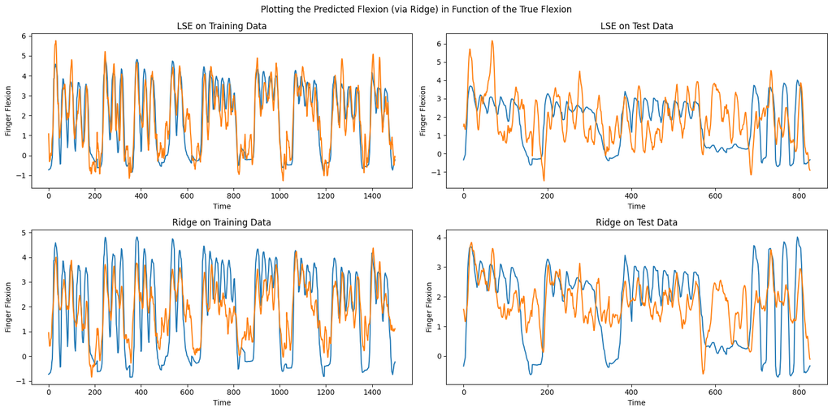

```python
fig, axs = plt.subplots(2,2, figsize = (16,8))

axs[0,0].plot(Y_train)
axs[0,0].plot(Y_train_pred)
axs[0,0].set_title("LSE on Training Data")
axs[0,0].set_ylabel("Finger Flexion")
axs[0,0].set_xlabel("Time")

axs[0,1].plot(Y_test)
axs[0,1].plot(Y_test_pred)
axs[0,1].set_title("LSE on Test Data")
axs[0,1].set_ylabel("Finger Flexion")
axs[0,1].set_xlabel("Time")

axs[1,0].plot(Y_train)
axs[1,0].plot(Y_train_pred_ridge)
axs[1,0].set_title("Ridge on Training Data")
axs[1,0].set_ylabel("Finger Flexion")
axs[1,0].set_xlabel("Time")

axs[1,1].plot(Y_test)
axs[1,1].plot(Y_test_pred_ridge)
axs[1,1].set_title("Ridge on Test Data")
axs[1,1].set_ylabel("Finger Flexion")
axs[1,1].set_xlabel("Time")

plt.suptitle("Plotting the Predicted Flexion (via Ridge) in Function of the True Flexion")
plt.tight_layout()
plt.show()
```

We can observe that even if the model overfits less the data the form of the signal predicted still different from the true one. Indeed even if fot values around the mean (2) the signal fits well it's not the case at all for values far from it (notably when the curve bumps to negative values).

Now let's compare the performances of this Ridge model with those of the LSE :

```python
MSE_train_ridge = mean_squared_error(Y_train, Y_train_pred_ridge)
MSE_test_ridge = mean_squared_error(Y_test, Y_test_pred_ridge)
R2_train_ridge = r2_score(Y_train, Y_train_pred_ridge)
R2_test_ridge = r2_score(Y_test, Y_test_pred_ridge)
```

```python
perfs.loc["Ridge"] = [MSE_train_ridge, MSE_test_ridge, R2_train_ridge, R2_test_ridge]
perfs
```

[output not shown]

- Ridge MSE and R2 show much less performance than LSE on training data, that's good news since the LSE is overfitting this training data.
- The R2 on the test data is still not satisfying for the Ridge regression.

```python
def compare_coefs(ax, coefs1, coefs2, legend, abs_ = False) :

    if abs_ :
        coefs1, coefs2 = np.abs(coefs1), np.abs(coefs2)
    markerline1, stemlines1, baseline1 = ax.stem(np.arange(Nb_features)-0.1125,coefs1 , linefmt='C0-', markerfmt=' ', basefmt='k-', label = legend[0] + ' Coefs')
    plt.setp(stemlines1, color ='tab:blue', linewidth=3.5)
    plt.setp(markerline1, 'color', 'tab:blue')
    plt.setp(baseline1, color='black', linewidth=0.2)

    markerline2, stemlines2, baseline2 = ax.stem(np.arange(Nb_features)+0.1125,coefs2, linefmt='C0-', markerfmt=' ', basefmt='k-', label = legend[1] + ' Coefs')
    plt.setp(stemlines2, color = 'tab:orange', linewidth=3.5)
    plt.setp(markerline2, 'color', 'tab:orange')
    plt.setp(baseline2, color='black', linewidth=0.2)

    return ax
```

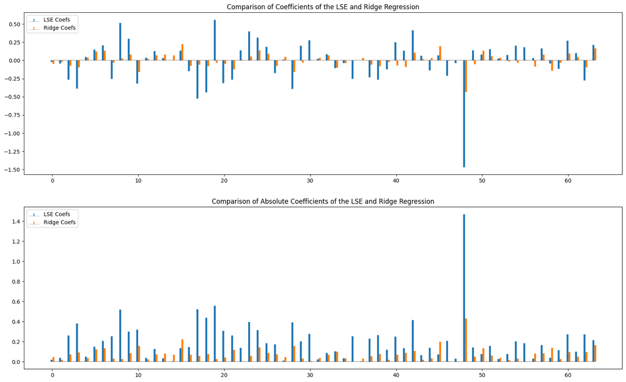

```python
ridge_coef = ridge.coef_
lse_coef = lin_reg.coef_[0]

fig, axs = plt.subplots(2,1,figsize = (20,12))

axs[0] = compare_coefs(axs[0], lse_coef, ridge_coef, ["LSE", 'Ridge'])
axs[0].legend(loc = 'upper left')
axs[0].set_title("Comparison of Coefficients of the LSE and Ridge Regression")

axs[1] = compare_coefs(axs[1], lse_coef, ridge_coef, ["LSE", 'Ridge'], abs_ = True)
axs[1].legend(loc = 'upper left')
axs[1].set_title("Comparison of Absolute Coefficients of the LSE and Ridge Regression")

plt.show()
```

Indeed ridge coefficients have a significantly lower absolute value. We can also note that the sign of the coef change when we're using the ridge regularization for the training.

```python
n = 15

ridge_coefs_abs = np.abs(ridge_coef)

indices_top_ridge = np.argpartition(ridge_coefs_abs, -n)[-n:]
indices_top_sorted_ridge = indices_top_ridge[np.argsort(ridge_coefs_abs[indices_top_ridge])[::-1]]
indices_top_sorted_ridge, indices_top_sorted
```

```
(array([48, 15, 45, 63, 10, 28, 24, 58, 50,  6,  5, 21, 42, 33, 60]),
 array([48, 19, 17,  8, 18, 42, 23, 28,  3, 10, 24, 20,  9, 30, 60]))
```

The top coefficients seems quite different, let's chceck their correlation :

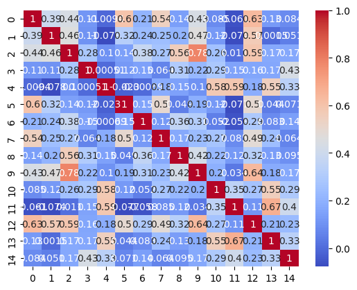

```python
sns.heatmap(pd.DataFrame(X[:, indices_top_sorted_ridge]).corr(), cmap='coolwarm', annot=True)
```

The Ridge regularization seems to have adessed the problem of intercorrelation but some correlated features seems to persist

# 5 - Lasso

```python
from sklearn.linear_model import Lasso
```

```python
lasso0 = Lasso()
lasso0.fit(X_train, Y_train)
y_pred_train_lasso = lasso0.predict(X_train)
y_pred_test_lasso = lasso0.predict(X_test)
```

```python
## Compute MSE
MSE_train_lasso = mean_squared_error(Y_train, y_pred_train_lasso)
MSE_test_lasso = mean_squared_error(Y_test, y_pred_test_lasso)
print("MSE train : ", MSE_train_lasso)
print("MSE test : ", MSE_test_lasso)

print("-------------------------")

## Compute R2
R2_train_lasso = r2_score(Y_train, y_pred_train_lasso)
R2_test_lasso = r2_score(Y_test, y_pred_test_lasso)
print("R2 train : ", R2_train_lasso)
print("R2 test : ", R2_test_lasso)
```

```
MSE train :  3.0519387154768376
MSE test :  1.758938674690965
-------------------------
R2 train :  0.0
R2 test :  -0.01937600321638122
```

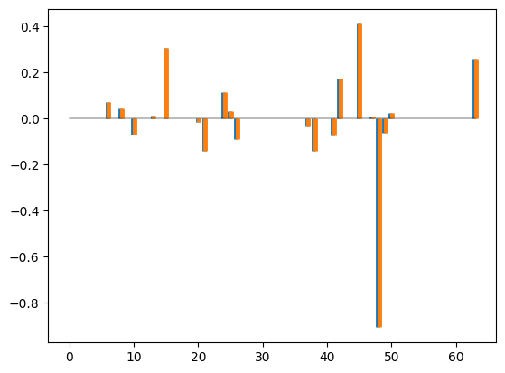

```python
fig, ax = plt.subplots(1,1)
ax = compare_coefs(ax, lasso.coef_, lasso.coef_, ['',''])
```

A lot of coefficient are null or negligible, Lasso Regression promotes sparsity.

Let's determine the best value of alpha we can use

```python
alphas = []
for k in range(-3,6) :
    alphas += [10 **k]
    alphas += [5*10 **k]
```

```python
lassos, lasso_MSEs_train, lasso_MSEs_val, lasso_MSEs_test, lasso_R2s_train, lasso_R2s_val, lasso_R2s_test, lasso_coefs, lasso_bias = search_alpha('lasso', alphas)
```

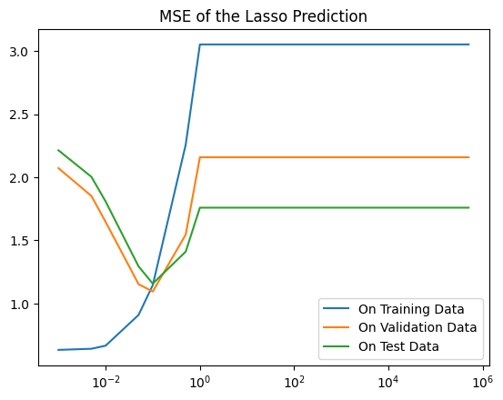

```python
plt.figure()
plt.plot(alphas, lasso_MSEs_train, label = 'On Training Data')
plt.plot(alphas, lasso_MSEs_val, label = 'On Validation Data')
plt.plot(alphas, lasso_MSEs_test, label = 'On Test Data')
plt.xscale('log')
plt.title("MSE of the Lasso Prediction")
plt.legend()
plt.show()
```

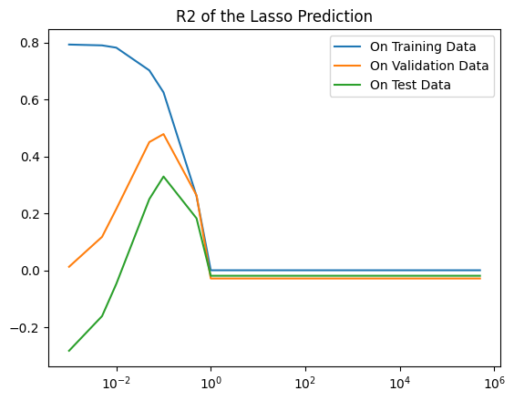

```python
plt.figure()
plt.plot(alphas, lasso_R2s_train, label = 'On Training Data')
plt.plot(alphas, lasso_R2s_val, label = 'On Validation Data')
plt.plot(alphas, lasso_R2s_test, label = 'On Test Data')
plt.xscale('log')
plt.title("R2 of the Lasso Prediction")
plt.legend()
plt.show()
```

On the MSE and the R2 we can observe the moment when all the coefficients are set to 0 (the performances are stationnary from this value of alpha)

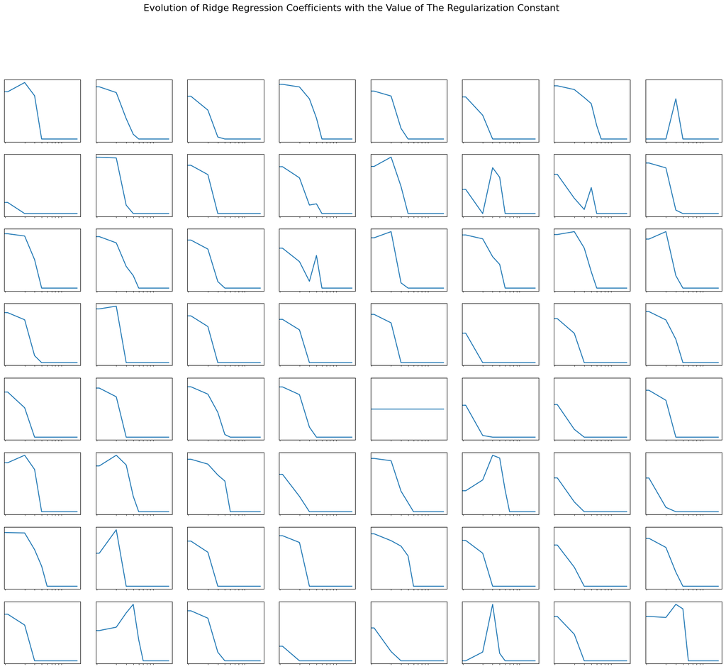

```python
display_coefs_evol(lasso_coefs)
plt.show()
```

We can observe that when alpha increases all the coefficients are abruptly going to 0

Now let's select the best lasso regressor

```python
lasso = lassos[np.argmin(lasso_MSEs_test)]
lasso
```

```
Lasso(alpha=0.1)
```

```python
Y_train_pred_lasso = lasso.predict(X_train)
Y_test_pred_lasso = lasso.predict(X_test)
```

```python
len(Y_train)
```

```
1500
```

```python
## Compute MSE
MSE_train_lasso = mean_squared_error(Y_train, Y_train_pred_lasso)
MSE_test_lasso = mean_squared_error(Y_test, Y_test_pred_lasso)
print("MSE train : ", MSE_train_lasso)
print("MSE test : ", MSE_test_lasso)

print("-------------------------")

## Compute R2
R2_train_lasso = r2_score(Y_train, Y_train_pred_lasso)
R2_test_lasso = r2_score(Y_test, Y_test_pred_lasso)
print("R2 train : ", R2_train_lasso)
print("R2 test : ", R2_test_lasso)
```

```
MSE train :  1.1452443951356117
MSE test :  1.1575474162970976
-------------------------
R2 train :  0.6247485608646379
R2 test :  0.32915452042937277
```

```python
perfs.loc['Lasso'] = [MSE_train_lasso, MSE_test_lasso, R2_train_lasso, R2_test_lasso]
perfs
```

[output not shown]

These are the best results we never had!

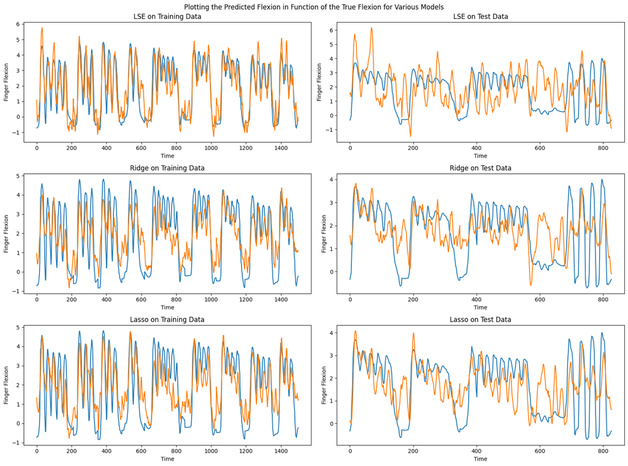

```python
fig, axs = plt.subplots(3,2, figsize = (16,12))

axs[0,0].plot(Y_train)
axs[0,0].plot(Y_train_pred)
axs[0,0].set_title("LSE on Training Data")
axs[0,0].set_ylabel("Finger Flexion")
axs[0,0].set_xlabel("Time")

axs[0,1].plot(Y_test)
axs[0,1].plot(Y_test_pred)
axs[0,1].set_title("LSE on Test Data")
axs[0,1].set_ylabel("Finger Flexion")
axs[0,1].set_xlabel("Time")

axs[1,0].plot(Y_train)
axs[1,0].plot(Y_train_pred_ridge)
axs[1,0].set_title("Ridge on Training Data")
axs[1,0].set_ylabel("Finger Flexion")
axs[1,0].set_xlabel("Time")

axs[1,1].plot(Y_test)
axs[1,1].plot(Y_test_pred_ridge)
axs[1,1].set_title("Ridge on Test Data")
axs[1,1].set_ylabel("Finger Flexion")
axs[1,1].set_xlabel("Time")

axs[2,0].plot(Y_train)
axs[2,0].plot(Y_train_pred_lasso)
axs[2,0].set_title("Lasso on Training Data")
axs[2,0].set_ylabel("Finger Flexion")
axs[2,0].set_xlabel("Time")

axs[2,1].plot(Y_test)
axs[2,1].plot(Y_test_pred_lasso)
axs[2,1].set_title("Lasso on Test Data")
axs[2,1].set_ylabel("Finger Flexion")
axs[2,1].set_xlabel("Time")

plt.suptitle("Plotting the Predicted Flexion in Function of the True Flexion for Various Models")
plt.tight_layout()
plt.show()
```

Visually lasso prediction looks like ridge one on training data but seems better for test data : the problems of depth identified in the Ridge prediction seem quite adessed, indeed the signal is going lower, a specificity which is fidel to the real signal.

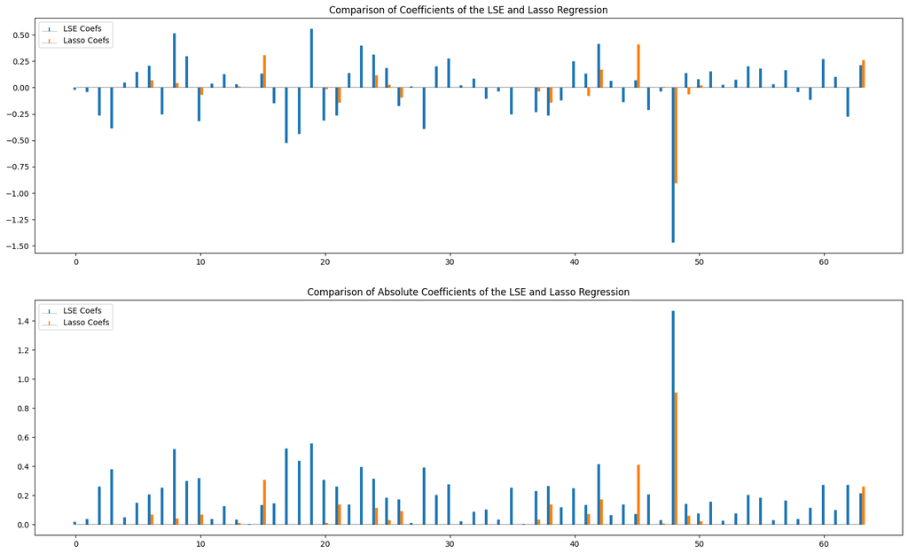

```python
lasso_coef = lasso.coef_
lse_coef = lin_reg.coef_[0]

fig, axs = plt.subplots(2,1,figsize = (20,12))

axs[0] = compare_coefs(axs[0], lse_coef, lasso_coef, ["LSE", 'Lasso'])
axs[0].legend(loc = 'upper left')
axs[0].set_title("Comparison of Coefficients of the LSE and Lasso Regression")

axs[1] = compare_coefs(axs[1], lse_coef, lasso_coef, ["LSE", 'Lasso'], abs_ = True)
axs[1].legend(loc = 'upper left')
axs[1].set_title("Comparison of Absolute Coefficients of the LSE and Lasso Regression")

plt.show()
```

```python
nb_zero_coef = np.sum(lasso_coef == 0)
nb_zero_coef
```

```
np.int64(44)
```

Let's compare these coefficients with the top coefficients of the Ridge Regression :

```python
abs_lasso_coefs = np.abs(lasso_coef)

indices_top_lasso = np.argpartition(abs_lasso_coefs, -n)[-n:]
indices_top_sorted_lasso = indices_top_lasso[np.argsort(abs_weights[indices_top_lasso])[::-1]]

indices_top_sorted_lasso, indices_top_sorted_ridge
```

```
(array([48,  8, 42, 10, 24, 38, 21, 37, 63,  6, 26, 49, 15, 41, 45]),
 array([48, 15, 45, 63, 10, 28, 24, 58, 50,  6,  5, 21, 42, 33, 60]))
```

The most important features has changed, let's display the correlation matrix

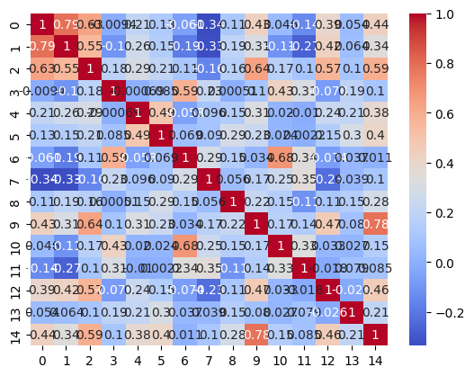

```python
sns.heatmap(pd.DataFrame(X[:, indices_top_sorted_lasso]).corr(), cmap='coolwarm', annot=True)
```

The Lasso regression contains more intercorrelation than the Ridge.

```python
feature_select = np.where(np.sort(np.abs(lasso_coef)) != 0)[0]
```

# 6 - Non Linear Regression

## Random Forest

```python
from sklearn.ensemble import RandomForestRegressor
```

```python
Y_train = Y_train.ravel()
```

```python
rfr0 = RandomForestRegressor()
rfr0.fit(X_train, Y_train)

y_pred_train_rfr = rfr0.predict(X_train)
y_pred_test_rfr = rfr0.predict(X_test)
```

```python
## Compute MSE
MSE_train_rfr = mean_squared_error(Y_train, y_pred_train_rfr)
MSE_test_rfr = mean_squared_error(Y_test, y_pred_test_rfr)
print("MSE train : ", MSE_train_rfr)
print("MSE test : ", MSE_test_rfr)

print("-------------------------")

## Compute R2
R2_train_rfr = r2_score(Y_train, y_pred_train_rfr)
R2_test_rfr = r2_score(Y_test, y_pred_test_rfr)
print("R2 train : ", R2_train_rfr)
print("R2 test : ", R2_test_rfr)

perfs
```

```
MSE train :  0.028358013572159894
MSE test :  1.4727105695104252
-------------------------
R2 train :  0.9907081969148489
R2 test :  0.1465047441146191
```

|  | MSE Train | MSE Test | R2 Train | R2 Test |
| --- | --- | --- | --- | --- |
| LSE | 0.63 | 2.27 | 0.79 | -0.32 |
| Ridge | 1.10 | 1.33 | 0.64 | 0.23 |
| Lasso | 1.15 | 1.16 | 0.62 | 0.33 |

For the random forest regressor default hyperparameters :

```python
import itertools

def manual_grid_search(model_class, param_grid, X_train, Y_train, X_test , Y_test, n_jobs=-1, random_state=42):

    best_r2 = -float('inf')
    best_params = None
    best_model = None

    # Generate all combinations of hyperparameters
    keys = list(param_grid.keys())
    values = list(param_grid.values())
    for combo in itertools.product(*values):
        params = dict(zip(keys, combo))

        # Add n_jobs and random_state if model supports them
        if 'n_jobs' in model_class().get_params().keys():
            params['n_jobs'] = n_jobs
        if 'random_state' in model_class().get_params().keys():
            params['random_state'] = random_state

        # Initialize and train model
        model = model_class(**params)
        model.fit(X_train, Y_train)

        # Predict on training data and compute performances
        y_pred = model.predict(X_test)
        r2 = r2_score(Y_test, y_pred)
        mse = mean_squared_error(Y_test, y_pred)

        # Update best if this is the highest R² so far
        if r2 > best_r2:
            best_r2 = r2
            best_mse = mse
            best_params = params
            best_model = model

    return best_model, best_params, best_r2, best_mse
```

```python
# Hyperparameters to test
param_grid = {
    'max_depth': [None, 2, 5, 10, 20, 30],
    'min_samples_leaf': [1, 2, 5, 10, 20],
    'max_features': [8, 14, 19, 25]
}

bm, bp, br2, bmse = manual_grid_search(RandomForestRegressor, param_grid, X_train, Y_train, X_val ,Y_val, n_jobs=-1, random_state=42)

print("Best MSE test : ", bmse)
print("Best R2 test : ", br2)
```

```
Best MSE test :  1.1866374931623713
Best R2 test :  0.4343589440268507
```

Still not satisfying, let's try to reduce the number of features according to the feature selection made by Lasso. Reduce the number of features should tackle overfitting problems.

```python
X_train_red, X_val_red = X_train[:,feature_select], X_val[:,feature_select]
```

```python
# Hyperparameters to test
param_grid = {
    'max_depth': [None, 2, 5, 10, 20, 30],
    'min_samples_leaf': [1, 2, 5, 10, 20],
}

bm_red, bp, br2, bmse = manual_grid_search(RandomForestRegressor, param_grid, X_train_red, Y_train, X_val_red,Y_val, n_jobs=-1, random_state=42)

print("Best MSE test : ", bmse)
print("Best R2 test : ", br2)
```

```
Best MSE test :  1.3644285324220187
Best R2 test :  0.3496103061581922
```

Seems like we lost too much information by cutting features. That means despite lower R2 the Random Forest Regressor reaches information in features that are not considered by the Lasso Regression.

```python
best_rfr = bm

y_pred_train_rfr = best_rfr.predict(X_train)
y_pred_test_rfr = best_rfr.predict(X_test)
```

```python
## Compute MSE
MSE_train_rfr = mean_squared_error(Y_train, y_pred_train_rfr)
MSE_test_rfr = mean_squared_error(Y_test, y_pred_test_rfr)
print("MSE train : ", MSE_train_rfr)
print("MSE test : ", MSE_test_rfr)

print("-------------------------")

## Compute R2
R2_train_rfr = r2_score(Y_train, y_pred_train_rfr)
R2_test_rfr = r2_score(Y_test, y_pred_test_rfr)
print("R2 train : ", R2_train_rfr)
print("R2 test : ", R2_test_rfr)

perfs.loc["RF Regressor"] = [MSE_train_rfr, MSE_test_rfr, R2_train_rfr, R2_test_rfr]
```

```
MSE train :  0.09387842067081237
MSE test :  1.2099549501020122
-------------------------
R2 train :  0.9692397425299726
R2 test :  0.2987822379176659
```

```python
perfs
```

|  | MSE Train | MSE Test | R2 Train | R2 Test |
| --- | --- | --- | --- | --- |
| LSE | 0.63 | 2.27 | 0.79 | -0.32 |
| Ridge | 1.10 | 1.33 | 0.64 | 0.23 |
| Lasso | 1.15 | 1.16 | 0.62 | 0.33 |
| RF Regressor | 0.09 | 1.21 | 0.97 | 0.30 |

## SVR

```python
from sklearn.svm import SVR
```

Let's train and evaluate the performances of a raw model

```python
svr0 = SVR()
svr0.fit(X_train, Y_train)

y_pred_train_svr = svr0.predict(X_train)
y_pred_test_svr = svr0.predict(X_test)
```

```python
## Compute MSE
MSE_train_svr = mean_squared_error(Y_train, y_pred_train_svr)
MSE_test_svr = mean_squared_error(Y_test, y_pred_test_svr)
print("MSE train : ", MSE_train_svr)
print("MSE test : ", MSE_test_svr)

print("-------------------------")

## Compute R2
R2_train_svr = r2_score(Y_train, y_pred_train_svr)
R2_test_svr = r2_score(Y_test, y_pred_test_svr)
print("R2 train : ", R2_train_svr)
print("R2 test : ", R2_test_svr)

perfs
```

```
MSE train :  0.022231136950165948
MSE test :  1.385113798818598
-------------------------
R2 train :  0.992715732843052
R2 test :  0.19727061064955398
```

|  | MSE Train | MSE Test | R2 Train | R2 Test |
| --- | --- | --- | --- | --- |
| LSE | 0.63 | 2.27 | 0.79 | -0.32 |
| Ridge | 1.10 | 1.33 | 0.64 | 0.23 |
| Lasso | 1.15 | 1.16 | 0.62 | 0.33 |
| RF Regressor | 0.09 | 1.21 | 0.97 | 0.30 |

As for the Random Forest there is overfitting

```python
param_grid = {
    'C': [0.01, 0.1, 1, 10, 100],
    'gamma': ['scale', 0.01, 0.1, 1],
    'epsilon': [0.01, 0.1, 0.2, 0.5]
}

bm, bp, br2, bmse = manual_grid_search(SVR, param_grid, X_train, Y_train, X_val ,Y_val, n_jobs=-1, random_state=42)

br2, bp
```

```
(0.44461810672640856, {'C': 1, 'gamma': 'scale', 'epsilon': 0.01})
```

```python
best_svr = bm

y_pred_train_svr = best_svr.predict(X_train)
y_pred_test_svr = best_svr.predict(X_test)
```

```python
## Compute MSE
MSE_train_svr = mean_squared_error(Y_train, y_pred_train_svr)
MSE_test_svr = mean_squared_error(Y_test, y_pred_test_svr)
print("MSE train : ", MSE_train_svr)
print("MSE test : ", MSE_test_svr)

print("-------------------------")

## Compute R2
R2_train_svr = r2_score(Y_train, y_pred_train_svr)
R2_test_svr = r2_score(Y_test, y_pred_test_svr)
print("R2 train : ", R2_train_svr)
print("R2 test : ", R2_test_svr)

perfs.loc["SVR"] = [MSE_train_svr, MSE_test_svr, R2_train_svr, R2_test_svr]
```

```
MSE train :  0.01624951627323175
MSE test :  1.377655312173253
-------------------------
R2 train :  0.9946756741245072
R2 test :  0.2015931048990537
```

```python
perfs
```

|  | MSE Train | MSE Test | R2 Train | R2 Test |
| --- | --- | --- | --- | --- |
| LSE | 0.63 | 2.27 | 0.79 | -0.32 |
| Ridge | 1.10 | 1.33 | 0.64 | 0.23 |
| Lasso | 1.15 | 1.16 | 0.62 | 0.33 |
| RF Regressor | 0.09 | 1.21 | 0.97 | 0.30 |
| SVR | 0.02 | 1.38 | 0.99 | 0.20 |

```python
from sklearn.neural_network import MLPRegressor
```

```python
mlp0 = MLPRegressor()
mlp0.fit(X_train, Y_train)

y_pred_train_mlp = mlp0.predict(X_train)
y_pred_test_mlp = mlp0.predict(X_test)
```

```python
## Compute MSE
MSE_train_mlp = mean_squared_error(Y_train, y_pred_train_mlp)
MSE_test_mlp = mean_squared_error(Y_test, y_pred_test_mlp)
print("MSE train : ", MSE_train_mlp)
print("MSE test : ", MSE_test_mlp)

print("-------------------------")

## Compute R2
R2_train_mlp = r2_score(Y_train, y_pred_train_mlp)
R2_test_mlp = r2_score(Y_test, y_pred_test_mlp)
print("R2 train : ", R2_train_mlp)
print("R2 test : ", R2_test_mlp)

perfs
```

```
MSE train :  0.006061513963692704
MSE test :  1.8266701407892842
-------------------------
R2 train :  0.9980138808381198
R2 test :  -0.05862912340570281
```

|  | MSE Train | MSE Test | R2 Train | R2 Test |
| --- | --- | --- | --- | --- |
| LSE | 0.63 | 2.27 | 0.79 | -0.32 |
| Ridge | 1.10 | 1.33 | 0.64 | 0.23 |
| Lasso | 1.15 | 1.16 | 0.62 | 0.33 |
| RF Regressor | 0.09 | 1.21 | 0.97 | 0.30 |
| SVR | 0.02 | 1.38 | 0.99 | 0.20 |

```python
param_grid = {
    'hidden_layer_sizes': [
        (50,), (100,), (50,50), (100,50), (100,100)
    ],
    'activation': ['relu', 'tanh'],
    'alpha': [0.1, 10, 100, 500, 1000, 5000],
    'learning_rate_init': [0.00001, 0.0001, 0.1],
    'solver': ['adam', 'lbfgs'],
    'max_iter' : [1000],
    'early_stopping' : [True]
}


bm, bp, br2, bmse = manual_grid_search(MLPRegressor, param_grid, X_train, Y_train, X_val ,Y_val, n_jobs=-1, random_state=42)

br2, bp
```

[output not shown]

Hyperparameters choice :

```python
mlp = bm

y_pred_train_mlp = mlp.predict(X_train)
y_pred_test_mlp = mlp.predict(X_test)
```

```python
## Compute MSE
MSE_train_mlp = mean_squared_error(Y_train, y_pred_train_mlp)
MSE_test_mlp = mean_squared_error(Y_test, y_pred_test_mlp)
print("MSE train : ", MSE_train_mlp)
print("MSE test : ", MSE_test_mlp)

print("-------------------------")

## Compute R2
R2_train_mlp = r2_score(Y_train, y_pred_train_mlp)
R2_test_mlp = r2_score(Y_test, y_pred_test_mlp)
print("R2 train : ", R2_train_mlp)
print("R2 test : ", R2_test_mlp)

perfs.loc["MLP"] = [MSE_train_mlp, MSE_test_mlp, R2_train_mlp, R2_test_mlp]
```

```
MSE train :  0.0873784975704461
MSE test :  1.5668297798411273
-------------------------
R2 train :  0.9713695110824682
R2 test :  0.09195886037614842
```

```python
perfs
```

|  | MSE Train | MSE Test | R2 Train | R2 Test |
| --- | --- | --- | --- | --- |
| LSE | 0.63 | 2.27 | 0.79 | -0.32 |
| Ridge | 1.10 | 1.33 | 0.64 | 0.23 |
| Lasso | 1.15 | 1.16 | 0.62 | 0.33 |
| RF Regressor | 0.09 | 1.21 | 0.97 | 0.30 |
| SVR | 0.02 | 1.38 | 0.99 | 0.20 |
| MLP | 0.09 | 1.57 | 0.97 | 0.09 |

On a grid search with a max_iteration value of 10000 the results are reaching those of the Lasso Regressor, but I didn't had the time to run this very long grid search on the final version of this notebook.

# Final Comparison of Performances

```python
print(perfs)
```

```
              MSE Train  MSE Test  R2 Train  R2 Test
LSE                0.63      2.27      0.79    -0.32
Ridge              1.10      1.33      0.64     0.23
Lasso              1.15      1.16      0.62     0.33
RF Regressor       0.09      1.21      0.97     0.30
SVR                0.02      1.38      0.99     0.20
MLP                0.09      1.57      0.97     0.09
```

In practice the Lasso Regression is the best model, closely followed by Random Forest Regressor. I had results almost equivalent to Lasso with MLP Regressor with a maximal iteration value of 10000 but since the associated grid search was too long to run these results won't be available on this final version.

Linear (especially Lasso) models are the most interpretable models

From a medical perspective the Lasso model is the better because it allows to reduce the number of captors to implement on the brain to predict finger movements, for exememple to design a prothesis replacing a lost finger.

This data seems to include some non linear elements as the LSE fails to predict well finger flexion and the non linear models (Random Forest Regressor) seems to get information that are not retained by the Lasso Linear Regression (since the performances are better when we use all the features than when we just use features selected by Lasso)

In this data the validation can be contested because of the form of the finger movmement signal. Indeed the form of this signal varies in different trends accross the training, validation and test data.

Conclusion : Next time I'll focus on the intercorrelation of features earlier in the study. Also it could be interesting to split the data based on the form of the signal, for example by extending the training data we can train the model on various trends of the signal ( maybe more data will be needed for this purpose).